# Do Supervised and Unsupervised Methods Agree on BRCA Subtypes?

DATS 6450, Multi-omic TCGA-BRCA at scale

Authors

Aidan Carlisle

Zachary Cardell

Published

May 5, 2026

Abstract

We ingest six TCGA-BRCA molecular modalities (RNA-seq, methylation, CNV, RPPA, miRNA, mutations) directly from a public S3 bucket, with 444 million rows of methylation alone (exceeding single-node memory), and ask whether **supervised** (XGBoost on PAM50 labels) and **unsupervised** (MOFA+ multi-omic factor analysis) approaches recover the same molecular structure on the integrated 6-view dataset. Both succeed and converge. XGBoost reaches 0.87 ± 0.01 5-fold-CV accuracy on PAM50, with 17 of 20 panel genes recovered in its top-50 SHAP features. MOFA+, given no labels, produces 14 active factors whose dominant factor loads jointly on all six modalities, and whose downstream k-means cluster is **97% pure Basal-like**. The two methods independently surface the same basal-vs-luminal axis, confirming it as the dominant structural signal in the data.

# Introduction

## Problem

> *On a multi-omic TCGA-BRCA dataset spanning six modalities and ~744 patients, do supervised and unsupervised analyses recover the same molecular-subtype structure?*

Breast cancer (BRCA) is heterogeneous. The **PAM50** transcriptional panel (Parker et al. 2009) divides it into five intrinsic subtypes (Basal, Her2, LumA, LumB, Normal-like) using only RNA-seq. PAM50 is the de facto label, but BRCA biology spans modalities PAM50 does not see: methylation, copy number, protein abundance, microRNA, somatic mutations. We ask whether a multi-omic representation either *(a)* lets a supervised classifier sharpen PAM50 prediction, or *(b)* lets an unsupervised model recover PAM50-like structure without ever seeing a label, and whether the two methods agree on what the dominant axis of variation is.

## Ten project questions

We organize the analysis around 10 specific questions.

**Exploratory (Q1–Q5):** feasibility, data quality, and feature-space sanity.

1. How does TCGA modality coverage funnel down to a multi-omic BRCA cohort?
2. Is methylation missingness technical or biological, and how does it interact with feature selection?
3. Are the most-recurrent BRCA mutations known cancer drivers (sanity)?
4. How does per-modality data volume scale, and where does single-node compute fail?
5. Does the merged six-view feature space preserve modality-specific structure or average it out?

**Supervised ML (Q6–Q7):** XGBoost on PAM50 with SHAP attribution.

6. Can XGBoost predict PAM50 subtypes from multi-omic features, and does it generalize to other cohorts?
7. Do the model’s top SHAP features match the published PAM50 marker panel?

**Unsupervised ML (Q8–Q10):** MOFA+ multi-omic factor analysis.

8. Does MOFA+ identify shared structure across all six modalities?
9. Does k-means clustering on those factors recover PAM50 subtypes?
10. Do the supervised and unsupervised methods converge on the same dominant biological axis?

# Dataset and Infrastructure

All data originate from the public TCGA mirror at `s3://tcga-2-open/`. The six BRCA modalities used here are summarized in Table 1. Methylation is the bottleneck modality: **444 million rows / 5.5 GB compressed**, ~30 GB decompressed, exceeding the 7.6 GB single-node memory budget if loaded eagerly.

Table 1: BRCA modality volumes after ingest. Methylation crosses the ‘big-data’ threshold.

|  | Modality | Schema | Rows | Compressed |
| --- | --- | --- | --- | --- |
| 0 | RNA-seq | gene × patient FPKM | 74.7 M | 1.6 GB |
| 1 | methylation | probe × patient β-value | 444 M | 5.5 GB |
| 2 | CNV | segment × patient log2 | 463 K | 7 MB |
| 3 | RPPA | peptide × patient | 443 K | 3.5 MB |
| 4 | miRNA | miRNA × patient RPM | 2.27 M | 7 MB |
| 5 | mutations | gene × patient (0/1) | 65 K | 0.4 MB |

Compute is a single AWS EC2 `t3` (2 vCPU, 7.6 GB RAM, no swap). To stay within memory, we use **DuckDB streaming** for any aggregation whose intermediate hash map is proportional to source rows (variance ranking on the methylation parquet) and **Polars lazy** scans (`scan_parquet().filter().select().collect(engine="streaming")`) for filter-and-project workloads. Eager `pl.read_parquet` on the methylation parquet reliably OOM-kills the instance, verified three times in development. A multi-node Spark-on-EC2 cluster is scaffolded but not on the critical path for the BRCA results below; the streaming patterns proved sufficient. Per-stage methods detail is in Appendix A.

The pipeline has four stages: ingest from S3 (per-modality readers in `src/ingest_*_polars.py`), wide-format merge with per-view feature pre-selection (`src/merge.py`), supervised classification (`code/run_classification_pipeline.py`), and unsupervised factor analysis (`code/run_mofa.py` and `code/analyze_mofa.py`).

# Exploratory Data Analysis

## Q1: Multi-omic cohort funnel

The 6-way intersection collapses 800 to 1,100 per-modality patients down to **744 multi-omic patients**, the analysis cohort for everything that follows.

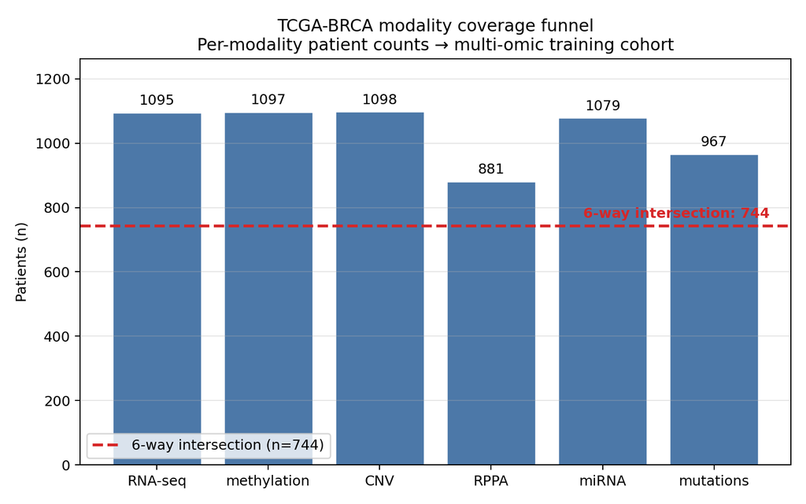

Figure 1: BRCA per-modality patient counts. The 6-way intersection (744 patients) defines the multi-omic training cohort.

## Q2: Methylation missingness, technical with consequences

Methylation missingness is bimodal. Most probes sit at the array’s ~18% baseline QC rate, but a long tail is **100% missing for TCGA-BRCA** (technical failures). A naive variance ranking selected those tail probes; adding a coverage gate (`HAVING COUNT(*) ≥ 80% × n_patients`) dropped merged 6-view methylation missingness from **36.3% to 26.7%**, with the per-column p90 falling below 30%.

The lesson: any feature-selection statistic computed on the long-format parquet must be coverage-gated *first*, not variance-ranked first and filtered after. Otherwise a probe with two non-null β-values produces huge “empirical variance” and dominates the top-N.

## Q3: Most-recurrent BRCA mutations are textbook drivers

The 2%-recurrence filter in `src/merge.py:_recurrent_mutated_genes` selects 193 BRCA genes. The top by recurrence are TP53 (basal/triple-neg), PIK3CA (luminal), GATA3 (luminal lineage), CDH1 (invasive lobular), and TTN, the textbook large-protein passenger that recurs by length alone.

## Q4: Methylation breaks single-node tools

Methylation at 444 M rows / 5.5 GB compressed (~30 GB decompressed) is the only modality that demands streaming; the other five fit comfortably in memory.

The need to handle the methylation parquet in DuckDB streams and Polars lazy collections is what makes the 6-view merge and downstream analyses possible on a single 7.6 GB node.

## Q5: Does the merged feature space preserve modality-specific signal?

# Supervised: XGBoost on PAM50

5-fold-CV accuracy is **0.867 ± 0.009** with macro-F1 **0.798 ± 0.027** on the 5-class PAM50 problem.

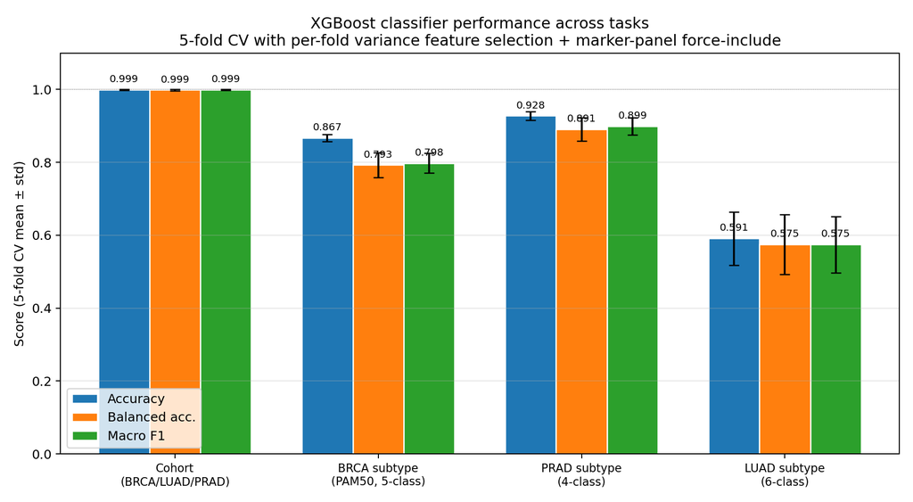

Figure 2: XGBoost performance on the BRCA PAM50 task and on cross-cohort sanity tasks. BRCA-PAM50 reaches 0.87 5-fold-CV accuracy. The 3-cohort separation task is saturating. LUAD subtypes are harder due to the 6-class × small-cohort combination (Appendix B).

The pipeline is 5-fold stratified XGBoost with per-fold variance re-ranking (top 500 features) plus **force-include** of PAM50 panel genes, so the published markers get a fair shot at appearing in SHAP rankings even if a fold’s variance ranking would have dropped them.

## Q7: Top SHAP features recover the PAM50 panel

**17 of 20 PAM50 panel genes** appear in the model’s top-50 features by mean |SHAP|, and **9 of 20 in the top-10**. This is strong external validation: the model’s notion of “what matters for PAM50” matches the panel built on independent intrinsic-subtype biology.

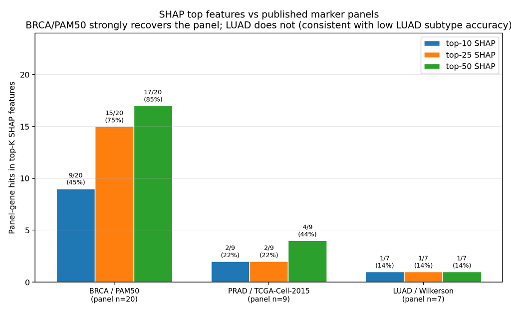

Figure 3: SHAP-vs-panel hits per cohort and rank window (top-10, top-25, top-50). BRCA / PAM50 strongly recovers the panel; LUAD does not, consistent with LUAD’s lower subtype accuracy (Appendix B).

Per-class SHAP plots (`data/classification_pipeline_brca/plots/shap_per_class/`) show subtype-specific drivers consistent with published intrinsic biology: **Basal** driven by FOXA1↓ + FOXC1↑, **Her2** by ERBB2 ranked #1, **LumA** by AURKA / CDC20 / ESR1 / BCL2.

# Unsupervised: MOFA+ on Six Modalities

## Q8: MOFA+ identifies a multi-omic dominant factor

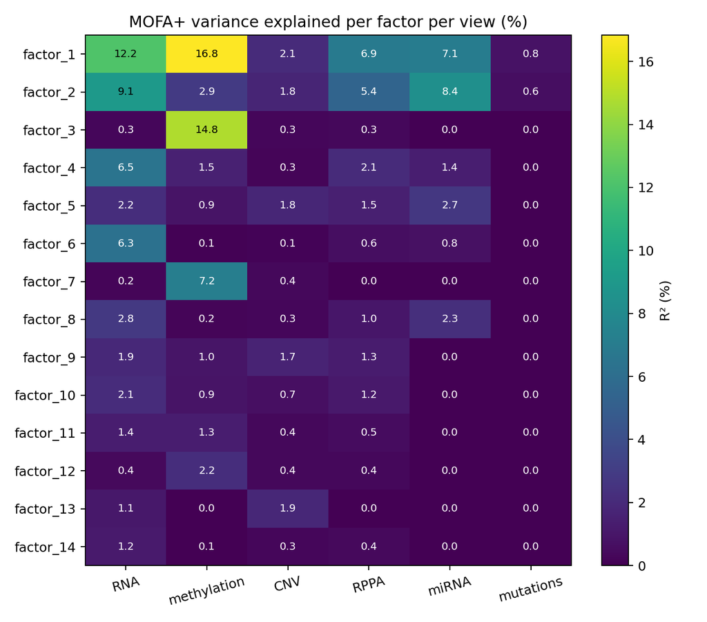

Figure 4: Variance explained per factor per view (%). Factor 1 is multi-omic across all six views (basal-vs-luminal axis); factor 2 captures a within-luminal proliferation gradient; factors 3 and 7 are methylation-specific.

Factor 1 R² across views: 12.2% RNA, 16.8% methylation, 2.1% CNV, 6.9% RPPA, 7.1% miRNA, 0.81% mutations. Top loadings on factor 1:

- **RPPA**: ESR1 (ERALPHA), GATA3, AR, PR. The canonical luminal hormone-receptor signature.
- **Mutations**: GATA3 and PIK3CA on the positive side; **TP53 negative**. This is the basal-vs-luminal driver-mutation split documented in TCGA Nature 2012.
- **miRNA**: miR-375, a well-known ER+ luminal marker miRNA.

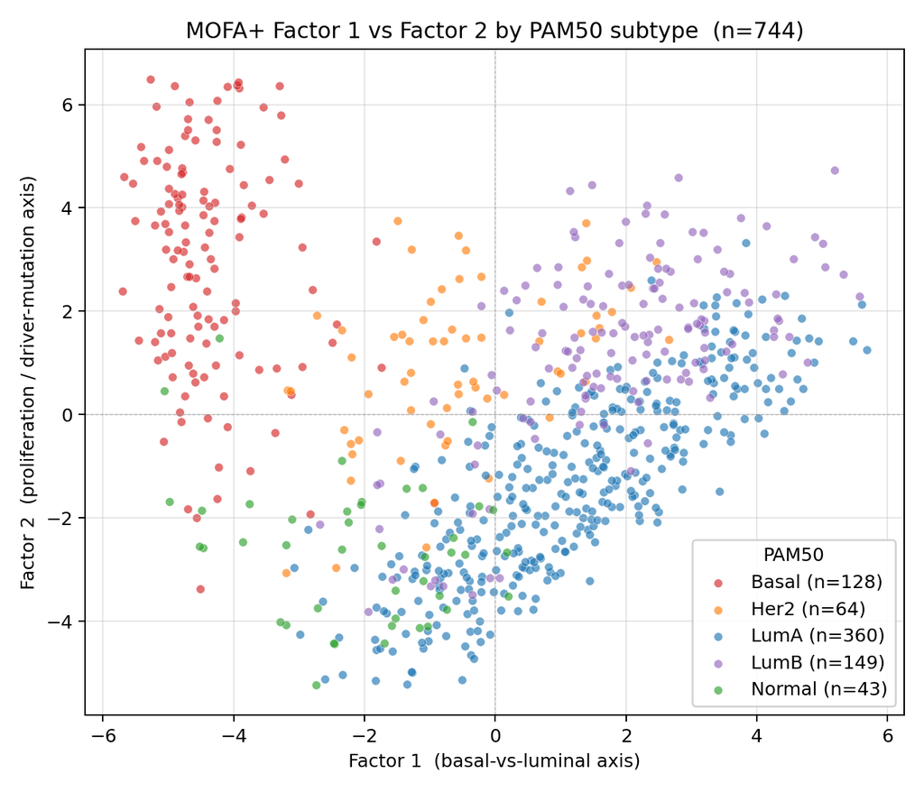

Figure 5: MOFA+ factor 1 vs factor 2, colored by PAM50 subtype. Factor 1 cleanly separates Basal (red) from luminal subtypes; factor 2 captures a within-luminal proliferation gradient.

## Q9: Clustering on factor scores partially recovers PAM50

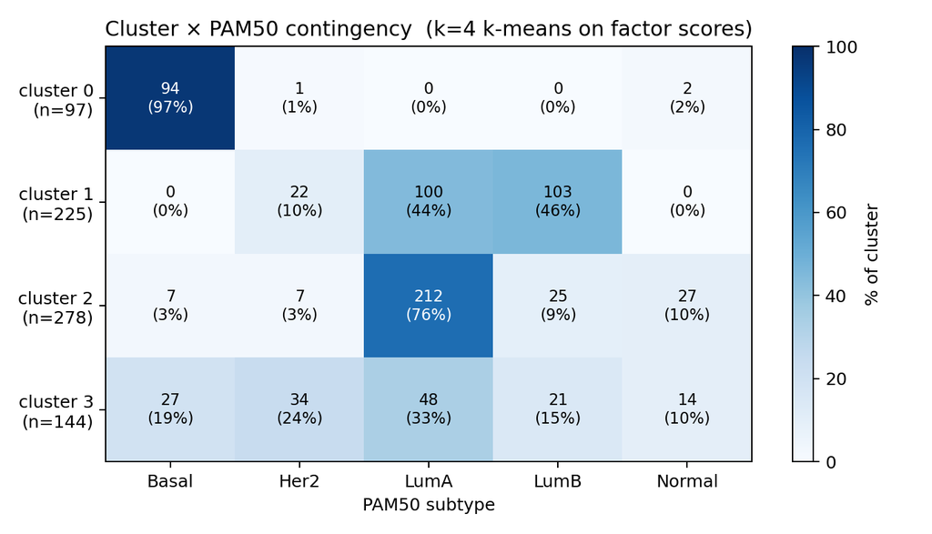

Figure 6: Cluster × PAM50 contingency at k=4. Cluster 0 is 97% pure Basal-like; cluster 2 is 76% LumA. Mixed clusters reflect genuine LumA / LumB / Her2 overlap on multi-omic axes.

The mid-range ARI is informative rather than a failure. PAM50’s LumA / LumB / Her2 boundaries are sharper in PAM50’s RNA-only definition than in the multi-omic factor space, which integrates CNV, methylation, RPPA, miRNA, and mutations contributing ~60% of total captured variance. Clusters 1 and 3 mixing LumA / LumB / Her2 reflects this.

## Q10: Supervised and unsupervised methods converge on the same axis

Both methods independently surface **basal-vs-luminal** as the dominant signal:

- The supervised XGBoost confusion matrix’s hardest *non-Basal* errors are LumA/LumB confusions; Basal is the cleanest class.
- The unsupervised MOFA+ factor 1 cleanly separates Basal from luminal subtypes (Figure 5), and the cleanest cluster (97% Basal-like) is the cluster MOFA+ would have chosen if forced to pick the easiest split first.
- The supervised top SHAP features (FOXA1, FOXC1, ESR1, ERBB2) and the unsupervised factor-1 loadings (ESR1/GATA3/AR/PR proteins, GATA3/PIK3CA vs TP53 mutations) describe the same hormone-receptor axis seen through two windows.

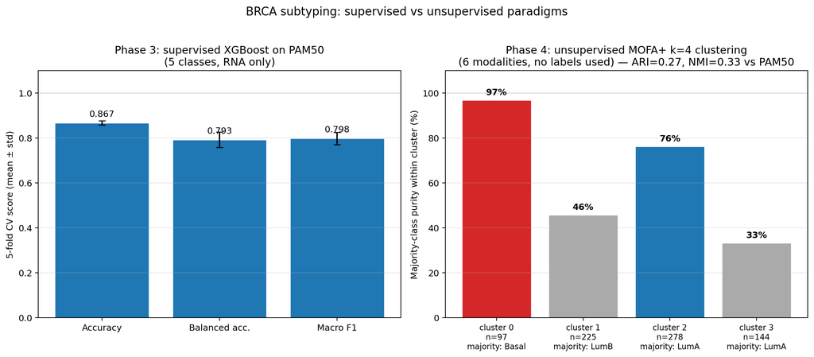

Figure 7: Side-by-side: supervised XGBoost on PAM50 labels (5 classes, 0.87 accuracy) vs unsupervised MOFA+ k=4 clustering (no labels, 97%-pure Basal cluster). Both methods succeed in their own framing and converge on the basal-vs-luminal axis.

With labels, the supervised model treats basal-vs-luminal as one axis among five it has to learn. Without labels, the unsupervised model picks that same axis as its #1 factor.

# Discussion

## Synthesis

The integrated 6-modality BRCA dataset has a dominant axis that both modeling approaches recover: basal-vs-luminal hormone-receptor biology. Supervised XGBoost confirms PAM50 is learnable (0.87 accuracy) and that its panel-defining genes are also the model’s most-attributing features (17 of 20 in top-50). Unsupervised MOFA+, given no labels, identifies the same axis as its dominant factor and recovers a 97%-pure Basal cluster downstream. The two methods answer different questions (*“can we predict labels?”* vs *“what structure does the data have?”*) and arrive at the same biological story.

## Limitations

- **No external validation cohort.** Metabric BRCA was scoped but not implemented; cross-platform harmonization (microarray to RNA-seq) is the principal obstacle.
- **Mid-range unsupervised ARI** (0.27–0.31) is below a high-agreement threshold but reflects genuine biology. Multi-omic factors capture cell-of-origin and methylation signal that PAM50 does not see. A fairer comparator would be an iCluster-style integrative subtype label.
- **Spark cluster scaffolded but not exercised.** All science ran on local DuckDB and Polars; the t3 instance was sufficient given memory discipline.

## Future work

Consensus clustering on MOFA+ factors (bootstrap resampling), Similarity Network Fusion (Wang et al. 2014) as an independent multi-omic comparator, external validation on Metabric, and Spark-cluster-driven pan-cancer scaling beyond the three cohorts.

# References

Parker, Joel S., Michael Mullins, Maggie C. U. Cheang, Samuel Leung, David Voduc, Tammi Vickery, Sherri Davies, et al. 2009. “Supervised Risk Predictor of Breast Cancer Based on Intrinsic Subtypes.” *Journal of Clinical Oncology* 27 (8): 1160–67. https://doi.org/10.1200/JCO.2008.18.1370.

Wang, Bo, Aziz M. Mezlini, Feyyaz Demir, Marc Fiume, Zhuowen Tu, Michael Brudno, Benjamin Haibe-Kains, and Anna Goldenberg. 2014. “Similarity Network Fusion for Aggregating Data Types on a Genomic Scale.” *Nature Methods* 11 (3): 333–37. https://doi.org/10.1038/nmeth.2810.

# Appendix

## A. Methods detail

**Per-view feature pre-selection.** RNA-seq and methylation: top 5,000 features by variance, gated on **≥ 80% non-null patient coverage** (the gate was critical for methylation; see Q2). RPPA, miRNA, CNV: kept all features. Mutations: kept genes mutated in **≥ 2% of cohort** (193 BRCA genes). Wide pivot then inner-join on `patient_id` produced the 744 × 12,612 multi-omic table.

**Supervised classifier.** `XGBoost.XGBClassifier` with 5-fold stratified CV. Per fold: re-rank features by variance and keep top 500, plus **force-include the PAM50 panel** so panel genes get a fair shot at appearing in SHAP rankings even when a fold’s variance would drop them. SHAP attribution via TreeExplainer; mean |SHAP| across folds defines the ranking compared against the panel.

**MOFA+.** Six views with five Gaussian likelihoods plus Bernoulli for mutations. Settings: 15 requested factors with ARD pruning, `convergence=medium`, `drop_factor_threshold=0.01`. Trained ~16 minutes over ~200 iterations on a single CPU; pruned to 14 active factors. Downstream k-means swept k=2..10; ARI and NMI computed against PAM50 at k=4.

## B. Cross-cohort sanity

To confirm the pipeline isn’t BRCA-specific, we ran the same XGBoost + SHAP pipeline on TCGA-LUAD (3 modalities, ~230 patients) and TCGA-PRAD (3 modalities). Results:

| Task | Accuracy | Macro F1 | Panel hits in top-50 |
| --- | --- | --- | --- |
| 3-cohort BRCA/LUAD/PRAD | 0.999 ± 0.001 | 0.999 ± 0.001 | n/a |
| BRCA / PAM50 (5-class) | 0.867 ± 0.009 | 0.798 ± 0.027 | 17/20 (PAM50) |
| PRAD subtype (4-class) | 0.928 ± 0.012 | 0.899 ± 0.023 | by-design (label leakage on ERG/ETV1) |
| LUAD subtype (6-class) | 0.591 ± 0.073 | 0.575 ± 0.077 | 1/7 (Wilkerson) |

LUAD’s low subtype accuracy reflects the 6-class × ~230-patient combination rather than a pipeline bug, and SHAP correspondingly fails to recover the Wilkerson panel. The pipeline scales to LUAD/PRAD but those results are not the focus of this report.

## C. Reproducibility

All code: https://github.com/acarlisle8/cancer_genome_atlas_research.

| Stage | Command | Wall time |
| --- | --- | --- |
| Ingest | `uv run python code/run_ingest.py` | ~30–60 min |
| Merge (6-view BRCA) | `uv run python code/run_merge_6view.py` | ~8 min |
| Supervised + SHAP | `uv run python code/run_classification_pipeline.py` | ~10 min |
| MOFA+ training | `uv run python code/run_mofa.py --cohort BRCA` | ~16 min |
| MOFA+ analysis | `uv run python code/analyze_mofa.py --model-dir data/mofa_BRCA` | <1 min |
| Render report | `quarto render final_report.qmd` | <30 s |

Compute: AWS EC2 `t3` (2 vCPU, 7.6 GB, no swap). Python 3.13 + uv.